# Cobinding PiPeline: pre processing & analysis

### merging

merging everything from additionals into the cobinding matrix

```python
merged.columns[:annot+1]
```

```
Index(['chrom', 'start', 'end', 'peak_number', 'foldchange', '-log10pvalue',
       '-log10qvalue', 'relative_summit_pos', 'CEBPA', 'HOXA9', 'PLAGL2',
       'MEIS1', 'ETV6', 'GFI1', 'RUNX1', 'FOSL2', 'FLI1', 'GATA2', 'SP1',
       'E2F3', 'ZNF281', 'SREBF1', 'LMO2', 'STAT5B', 'ZMYND8', 'LYL1', 'MYC',
       'TFAP4', 'RUNX2', 'MAX', 'IRF8', 'MYB', 'ZEB2', 'RXRA', 'SPI1', 'MEF2C',
       'FLAG_MEF2D', 'activation'],
      dtype='object')
```

```python
#chrombed['foldchange']= chrombed['state']
#merged['HMM_states'] = chip.putInBed(merged[merged.columns[:cols]], chrombed, window=1, mergetype='first')
for key, val in additional.items():
    if key in merged.columns:
        continue
    print(key)
    if len(val)>1 and key not in ['FLAG_MEF2C']:
        merged[key] = chip.putInBed(merged[merged.columns[:cols]],val)
merged = merged.replace(np.nan,0)
```

[output not shown]

#### total size of the cobinding matrix on the DNA

```python
sum([v['end'] - v["start"] for k, v in merged.iterrows()])
```

```
94143114
```

```python
## making regular enhancers from otherr annotations
merged['regular_enhancer'] = (merged['activation'].astype(bool) & ~merged['super_enhancer'].astype(bool) & ~merged['promoters'].astype(bool)).astype(float)
```

[output not shown]

```python
#setting each state as a separate annotation
for i in range(1,1+numstates):
    merged['state_'+str(i)] = (merged.HMM_states==i).astype(float)
merged = merged.drop(columns=['HMM_states'])
# renaming
merged = merged.rename(columns=rn)
```

```python
merged = merged.drop(columns="FLAG_MEF2C")
```

```python
merging_version="remove_single"
window="150"
version
```

```
'v3'
```

```python
merged.to_csv('../results/'+project+'/merged_'+version+'_'+merging_version+'_'+window+'_with_annotations.bed.gz', sep='\t',index=None)
```

```python
merged = pd.read_csv('../results/'+project+'/merged_'+version+'_'+merging_version+'_'+window+'_with_annotations.bed.gz', sep='\t')
```

## In depth look at the cobinding matrix

```python
# Showing Basic Information about each annotations
info = pd.concat([merged[merged.columns[cols:]].astype(bool).sum(0),
           merged[merged.columns[cols:]].max(),
           merged[merged.columns[cols:]].replace(0, np.NaN).mean(),
          merged[merged.columns[cols:]].replace(0, np.NaN).var()],axis=1).rename(columns={0:'sum',1:'max',2:'mean',3:'std'})
info.to_csv('../results/'+project+'/'+version+'_'+merging_version+'_'+window+'info.tsv')
info.iloc[:60]
```

|  | sum | max | mean | std |
| --- | --- | --- | --- | --- |
| CEBPA | 63966 | 123.662740 | 10.046960 | 56.318815 |
| HOXA9 | 1280 | 36.844650 | 7.168257 | 11.645595 |
| PLAGL2 | 14020 | 1424.570000 | 8.466919 | 276.708884 |
| MEIS1 | 54446 | 99.050100 | 10.005325 | 98.527080 |
| ETV6 | 6789 | 80.067433 | 9.770706 | 41.293722 |
| FLAG_GFI1 | 23462 | 82.751400 | 5.936747 | 29.822003 |
| RUNX1 | 52877 | 85.437050 | 8.370491 | 24.175058 |
| FOSL2 | 4248 | 367.017000 | 10.631119 | 124.359614 |
| FLI1 | 54412 | 512.890000 | 16.070863 | 433.097705 |
| GATA2 | 11751 | 191.227000 | 16.593435 | 363.723332 |
| SP1 | 24194 | 684.427000 | 14.831084 | 413.250456 |
| E2F3 | 14952 | 598.145000 | 11.179151 | 145.030404 |
| ZNF281 | 17264 | 3947.190000 | 23.475589 | 7177.474375 |
| SREBF1 | 4167 | 645.240000 | 7.143158 | 172.918691 |
| LMO2 | 15372 | 43.670685 | 6.623292 | 11.148511 |
| STAT5B | 29267 | 293.239000 | 6.153930 | 107.333358 |
| ZMYND8 | 21690 | 45.176050 | 7.411136 | 12.582586 |
| LYL1 | 11903 | 89.225000 | 8.936873 | 54.257880 |
| MYC | 60303 | 83.149145 | 5.650239 | 16.645478 |
| TFAP4 | 27752 | 1356.100000 | 8.787612 | 175.358419 |
| RUNX2 | 74080 | 75.824667 | 9.455531 | 61.040245 |
| MAX | 69353 | 110.474250 | 10.180252 | 61.991966 |
| IRF8 | 60080 | 259.973103 | 11.160784 | 167.689413 |
| MYB | 24691 | 125.953500 | 8.417554 | 49.572856 |
| ZEB2 | 8128 | 812.188933 | 7.410626 | 236.043888 |
| RXRA | 14295 | 1240.170000 | 7.334447 | 168.826353 |
| SPI1 | 79256 | 200.846033 | 14.353612 | 145.678314 |
| MEF2C | 20696 | 84.652118 | 5.361940 | 11.055816 |
| FLAG_MEF2D | 22863 | 133.333967 | 4.333344 | 5.385800 |
| activation | 85159 | 29.194000 | 5.703074 | 22.104275 |
| repression | 39036 | 17.297600 | 3.966265 | 1.762233 |
| ELF2 | 34813 | 114.326900 | 11.602887 | 89.426821 |
| JUND | 3167 | 63.074500 | 5.606189 | 5.342223 |
| FLAG_SPI1 | 88477 | 64.507200 | 15.533735 | 151.056356 |
| FLAG_IRF2BP2 | 16186 | 30.638700 | 4.817594 | 3.451253 |
| SMC1 | 40516 | 86.709700 | 9.913393 | 80.169167 |
| LDB1 | 89 | 30.134700 | 9.093212 | 22.544892 |
| H3K79me2 | 23769 | 16.227400 | 5.376421 | 6.072910 |
| WDR5 | 568 | 42.445660 | 9.306264 | 52.079075 |
| H3K27ac | 55611 | 18.188992 | 4.475398 | 3.721186 |
| H3K27me3 | 3959 | 16.938800 | 3.969991 | 1.109925 |
| MYBL2 | 307 | 35.384400 | 8.556340 | 19.602319 |
| CDK9 | 46016 | 65.188600 | 5.590581 | 8.084956 |
| H3K4me3 | 23977 | 29.194000 | 11.895355 | 34.069569 |
| FOXP1 | 42518 | 78.395000 | 6.829304 | 17.183713 |
| MLL_KTM2A | 33191 | 17.241300 | 4.817601 | 1.328124 |
| RARA | 5122 | 343.553000 | 8.057540 | 79.916821 |
| IKZF1 | 28302 | 75.841100 | 6.872853 | 12.946234 |
| AFF4 | 3135 | 96.589900 | 5.648181 | 14.847186 |
| CTCF | 16485 | 77.679100 | 19.157070 | 126.645379 |
| BRD4 | 44296 | 13.187515 | 3.927379 | 1.001922 |
| CEBPB | 54962 | 150.145000 | 9.401663 | 89.242951 |
| H3K36me2 | 36006 | 17.297600 | 3.947916 | 1.825128 |
| PSER2 | 23811 | 59.964700 | 7.819262 | 50.726616 |
| H3K36me3 | 9442 | 14.576100 | 3.630236 | 1.103305 |
| H3K9ac | 41116 | 20.637600 | 5.751262 | 11.299117 |
| CDK13 | 88 | 75.114900 | 7.155730 | 73.542508 |
| H3K4me1 | 46866 | 5.403210 | 2.998577 | 0.128671 |
| POLII | 32269 | 94.570360 | 4.171626 | 10.517348 |
| MED1 | 35803 | 29.567060 | 3.876440 | 1.548870 |

```python
info.iloc[60:]
```

|  | sum | max | mean | std |
| --- | --- | --- | --- | --- |
| super_enhancer | 9617 | 36.169492 | 6.166133 | 12.789154 |
| promoters | 10132 | 1.000000 | 1.000000 | 0.000000 |

```python
merged.columns
```

```
Index(['chrom', 'start', 'end', 'peak_number', 'foldchange', '-log10pvalue',
       '-log10qvalue', 'relative_summit_pos', 'CEBPA', 'HOXA9', 'PLAGL2',
       'MEIS1', 'ETV6', 'GFI1', 'RUNX1', 'FOSL2', 'FLI1', 'GATA2', 'SP1',
       'E2F3', 'ZNF281', 'SREBF1', 'LMO2', 'STAT5B', 'ZMYND8', 'LYL1', 'MYC',
       'TFAP4', 'RUNX2', 'MAX', 'IRF8', 'MYB', 'ZEB2', 'RXRA', 'SPI1', 'MEF2C',
       'FLAG_MEF2D', 'activation', 'repression', 'ELF2', 'JUND', 'FLAG_SPI1',
       'FLAG_IRF2BP2', 'SMC1', 'LDB1', 'H3K79me2', 'WDR5', 'H3K27ac',
       'H3K27me3', 'FLAG_GFI1', 'MYBL2', 'CDK9', 'H3K4me3', 'FOXP1',
       'MLL_KTM2A', 'RARA', 'IKZF1', 'AFF4', 'CTCF', 'BRD4', 'CEBPB',
       'H3K36me2', 'PSER2', 'FLAG_MEF2C', 'H3K36me3', 'H3K9ac', 'CDK13',
       'H3K4me1', 'POLII', 'MED1', 'super_enhancer'],
      dtype='object')
```

```python
touse = ['activation', 'repression', 'FLAG_IRF2BP2', 'cohesin', 'H3K79me2', 'H3K27me3', 'H3K27ac','H3K4me3', 'FOXP1', 'MLL_KTM2A', 'RARA', 'IKZF1','H3K18', 'H3K36me2', 'H3K36me3', 'H3K9ac', 'H3K4me1', 'POLII', 'mediator', 'open regions', 'promoters', 'super_enhancer', 'regular_enhancer']
```

```python
rand = np.random.choice(merged.index,5000)
viridis = cm.get_cmap('viridis', 256)

data = merged[merged.columns[annot:]]
ma = data.max()
mi = data.min()
data = data.loc[rand]
data = (data-mi)/(ma-mi)
for val in data.columns:
    a = [viridis(int(v*256)) for v in data[val]]
    data[val] = a
```

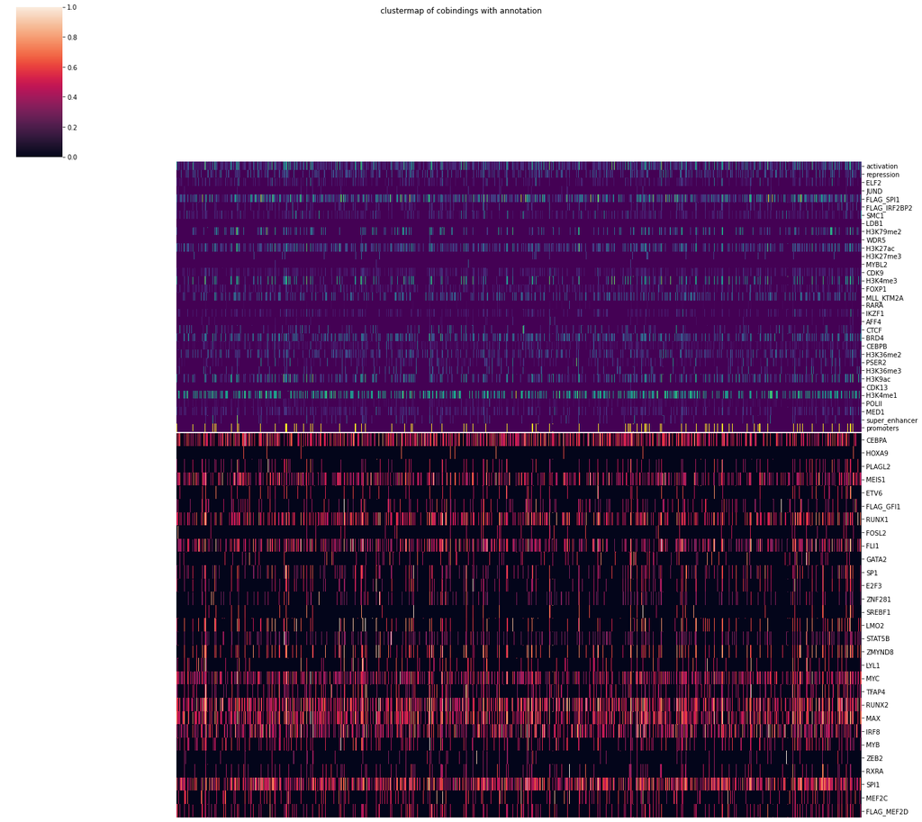

```python
#clustermap of cobindings with annotation
fig = sns.clustermap(np.log2(1.01+merged[merged.columns[cols:annot]].loc[rand].T), standard_scale=0, colors_ratio=0.01, figsize=(20,18), col_colors = data, xticklabels=False, row_cluster=False, col_cluster=False)
fig.ax_col_dendrogram.set_visible(False)
fig.fig.suptitle("clustermap of cobindings with annotation")

fig.savefig('../results/'+project+'/plots/'+version+'_'+merging_version+'_'+window+'_clustermap_cobinding_scaled_full_annotations.pdf')
plt.show()
```

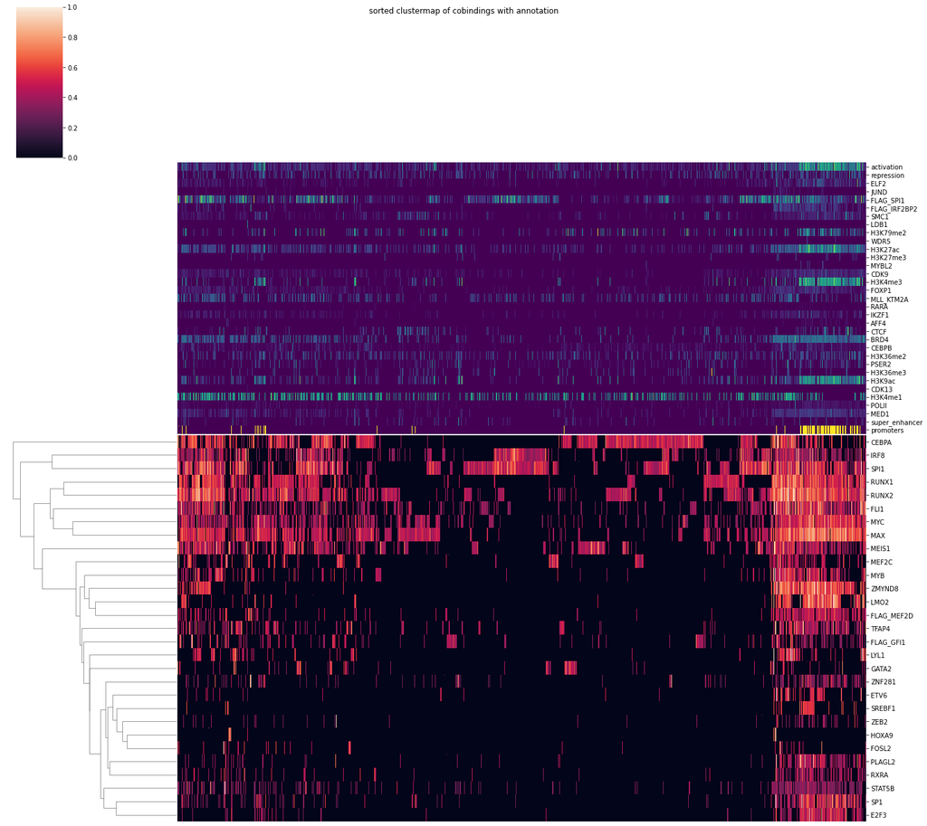

```python
#sorted clustermap of cobindings with annotation
fig = sns.clustermap(np.log2(1.01+merged[merged.columns[cols:annot]].loc[rand].T), vmin=0, vmax=1, figsize=(20,18), colors_ratio=0.01, standard_scale=0, col_colors=data, xticklabels=False)
fig.ax_col_dendrogram.set_visible(False)
fig.fig.suptitle("sorted clustermap of cobindings with annotation")
fig.savefig('../results/'+project+'/plots/'+version+'_'+merging_version+'_'+window+'_clustermap_cobinding_scaled_full_annotation_sorted.pdf')
plt.show()
```

```python
#scatter plot of distance of TF in cobinding space
plot.scatter(TSNE(2,3).fit_transform(PCA(10).fit_transform(stats.zscore(merged[merged.columns[cols:annot]]).T)), radi=10, labels=merged.columns[cols:annot], showlabels=True, title="scatter plot of distance of TF in cobinding space", folder="../results/"+project+'/plots/'+version+"_"+window+"_"+merging_version+"_")
```

[interactive chart not shown]

```python
#TODO send TSNE coordinates
```

```python
#scatter plot of distance of TF in cobinding space
plot.scatter(TSNE(2,5).fit_transform(stats.zscore(merged[merged.columns[cols:]]).T), radi=5, labels=merged.columns[cols:], colors=[1 if val in crc else 0 for val in merged.columns[cols:]], showlabels=True, title="scatter plot of distance of TF in cobinding space", folder="../results/"+project+'/plots/'+version+"_"+window+"_"+merging_version+"_")
```

[interactive chart not shown]

## Comparison to a random distribution

### computation:

we are evalutating each event's probability 1 binding, 2 binding, n binding.., as a binomial over the amount of proability p_i with n retries corresponding to the size of the conscensus peak set. the probability p_i of this binomial is the sum of probabilities of having tf a binding with b for all possible combination of tf. the number of combination is k amongst n, n being 33, k going from 1 to 29 we compute

$p(a & b) = p(a)\*p(b) =p(ab)$

and

$p(a & b) | p(a & c) = p(ab) + p(ac) - p(abc)$

for a,b,c,d:

$p(ab) + p(ac) + p(ad) + p(bc) + p(bd) + p(cd) - {3\choose 2}*(p(abc) - p(abd) - p(bcd) - p(acd)) - {4\choose 2}*p(abcd)$

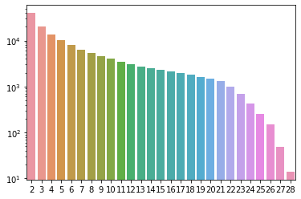

```python
#we are looking at the distribution of pseudo-enhancers per cobound regions
counts,val = np.unique(merged[merged.columns[cols:annot]].astype(bool).sum(1).values, return_counts=True)
fig = sns.barplot(data=pd.DataFrame(val, index=counts,columns=['counts']).T)
fig.set_yscale("log")
fig.figure.savefig("../results/"+project+'/plots/'+version+'_'+merging_version+'_'+window+"_cobinding_distribution.pdf")
```

now we will be making the expected distribution

```python
proba = (merged[merged.columns[cols:annot]].astype(bool).sum(0)/len(merged)).tolist()
size= len(proba)+1
sums = helper.makeCombinations(size, proba)
```

```
29
40920
28
237336
27
1107568
26
4272048
25
13884156
24
38567100
23
92561040
22
193536720
21
354817320
20
573166440
19
818809200
18
1037158320
17
1166803110
16
1166803110
15
1037158320
14
818809200
13
573166440
12
354817320
11
193536720
10
92561040
9
38567100
8
13884156
7
4272048
6
1107568
5
237336
4
40920
3
5456
2
528
1
33
```

```python
# we are saving the expected distributions (as it is long to compute)
version = "v3"
merging_version = "simpleMerge"
window = "150"
a = '../results/' + project + '/*_sums.json'
!ls $a
```

```
../results/Cobinding_ChIP/v2_simpleMerge_150_sums.json
../results/Cobinding_ChIP/v3_remove_single_150_sums.json
```

```python
helper.dictToFile(sums,'../results/' + project + '/' + version + '_' + merging_version +  '_' + window+'_sums.json')
```

```python
sums = helper.fileToDict('../results/' + project + '/' + version + '_' + merging_version +  '_' + window+'_sums.json')
s={}
for k,v in sums.items():
    s[int(k)] = sums[k]
sums = s
sums
```

```
{1: [39375.860078915546, 34923.44986335529],
 2: [76716.90416390114, 59815.717345763675],
 3: [89118.55996666614, 66311.39074603183],
 4: [69924.20433202894, 55883.46001875424],
 5: [39675.96204361759, 35155.42537353387],
 6: [16985.826924230558, 16157.296513782503],
 7: [5643.449017645179, 5551.990475091973],
 8: [1483.6170522529567, 1477.2961554932504],
 9: [312.79780139758947, 312.5168297824765],
 10: [53.375991275489014, 53.36780988782561],
 11: [7.41462658780752, 7.414468712709706],
 12: [0.8410055063481038, 0.8410034752413845],
 13: [0.07792649977851888, 0.07792648234016836],
 14: [0.005886971356911155, 0.005886971257389197],
 15: [0.000360940508241245, 0.00036094050786712896],
 16: [1.782563613035323e-05, 1.7825636129440745e-05],
 17: [7.012370592554538e-07, 7.012370592540417e-07],
 18: [2.1624717493410227e-08, 2.1624717493408884e-08],
 19: [5.109804899071793e-10, 5.109804899071786e-10],
 20: [8.950256644409812e-12, 8.950256644409812e-12],
 21: [1.1050812349490646e-13, 1.1050812349490646e-13],
 22: [8.859337871516564e-16, 8.859337871516564e-16],
 23: [3.9670801623365564e-18, 3.9670801623365564e-18],
 24: [7.199206194144114e-21, 7.199206194144114e-21],
 25: [4.87380052588187e-24, 4.87380052588187e-24],
 26: [8.594804171604625e-28, 8.594804171604625e-28],
 27: [0.0, 0.0],
 28: [0.0, 0.0],
 29: [0.0, 0.0],
 0: 0.02564433979655356}
```

```python
# computing the ratio to expected distribution
for i in range(len(sums)-1,0,-1):
    print(i,stats.binom.mean(len(merged), sums[i]),stats.binom.var(len(merged), sums[i]))
    sums[i] = [stats.binom.mean(len(merged), sums[i]),stats.binom.var(len(merged), sums[i])]
```

```
29 2.48389575677425e-19 2.48389575677425e-19
28 7.915266711593065e-17 7.915266711593065e-17
27 1.0749724000851412e-14 1.0749724000851412e-14
26 8.55850130045669e-13 8.55850130045669e-13
25 4.565567188993047e-11 4.565567188993046e-11
24 1.7565409491237836e-09 1.7565409491237613e-09
23 5.10498057594738e-08 5.1049805759455026e-08
22 1.1565217622801782e-06 1.1565217622705404e-06
21 2.0885857843389227e-05 2.0885857840246054e-05
20 0.00030563131471884354 0.0003056313140457748
19 0.0036682527834880126 0.003668252686530327
18 0.0364365484949851 0.036436538928812975
17 0.30148563819282365 0.30148498325965434
16 2.087447909201491 2.0874165117048693
15 12.128805068313053 12.127745083211238
14 59.21867958861897 59.19341098935091
13 242.95441481896754 242.52909725355948
12 836.4247759670118 831.3837665793241
11 2409.864008667793 2368.0185049658094
10 5786.652485951751 5545.3740369113675
9 11514.22456429327 10558.939210056984
8 18839.705608763983 16282.227333867973
7 25091.533089638462 20555.062248192306
6 26835.498189825823 21646.505567558364
5 22626.510168067492 18937.593208600832
4 14654.514114151249 13107.099921333265
3 7014.588910940416 6660.046513172042
2 2331.532283189374 2292.3629123906862
1 479.3908843401743 477.7349493914525
```

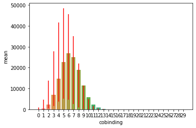

```python
cobind = pd.DataFrame(sums).T.rename(columns={0:'mean',1:'var'})
cobind['cobinding']=cobind.index
fig = sns.barplot("cobinding","mean", data=cobind, ci=None)
plt.errorbar(x=range(0,len(cobind)),y=cobind['mean'],
            yerr=cobind['var'], fmt='none', c= 'r')
plt.savefig("../results/"+project+'/plots/'+version+'_'+merging_version+'_'+window+"_expected_cobinding_distribution.pdf")
```

Let's look at the enrichment of our current dataset

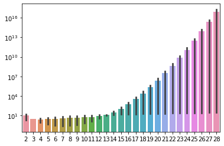

```python
res = pd.DataFrame()
res['change']=val/cobind[cobind.cobinding.isin(counts)]['mean']
res['count']=list(res.index)
fig = sns.barplot(data=res.T).set_yscale("log")
plt.savefig("../results/"+project+'/plots/'+version+'_'+merging_version+'_'+window+"_cobinding_enrichment.pdf")
```

now plotting the enrichment compared to expected distribution

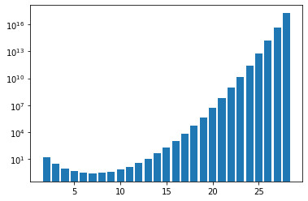

```python
fig = plt.bar(res['count'],res['change'],log=True)
plt.savefig("../results/"+project+'/plots/'+version+'_'+merging_version+'_'+window + "_cobinding_enrichment_matplotlib.pdf")
plt.show()
```

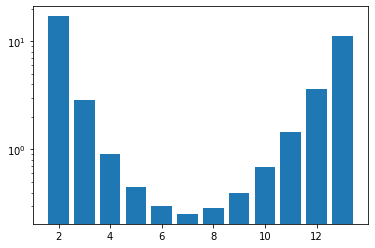

```python
m =12
fig = plt.bar(res.iloc[:m]['count'],res.iloc[:m]['change'],log=True)
plt.savefig("../results/"+project+'/plots/'+version+'_'+merging_version+'_'+window+"_cobinding_enrichment_zoomed.pdf")
plt.show()
```

## Saving

```python
%store merged
%store chrombed
%store mergedpeak
%store cols
%store annot
%store version
%store merging_version
%store window
%store crc
```

```
Stored 'merged' (DataFrame)
Stored 'chrombed' (DataFrame)
Stored 'mergedpeak' (DataFrame)
Stored 'cols' (int)
Stored 'annot' (int)
Stored 'version' (str)
Stored 'merging_version' (str)
Stored 'window' (str)
```